# Inferential R Analysis Guide

This document provides an introduction to the commands you’ll need to do statistical inference (i.e. doing statistical tests and generating confidence intervals) for EPSY 5261 in R.

This document assumes that you have already read through “Getting Started with R and R Studio”, and worked through the “Basic R Analysis Guide.Rmd”. Note that this document requires loading a new package: `tidyr` for rearranging data. You don’t need to install anything new, however, because this package is already installed on your system when you installed the package `mosaic`.

## Preparing to run this document

Before running the code in this document, please:

1. Make sure you have installed the packages `rmarkdown`, `mosaic`, and `readr`. These should not be new packagaes to you :)
2. Download **GenderPolitics.csv**, **GPA-SAT.csv**, **StudyHours.csv**, **TestScores2.csv**, and **VocabKnowledge.csv** and put them in the same folder on your computer as this file so R can reference the same *directory*.

## Loading packages

Again, we load the same core packages that we used in the Basic R Analysis Guide.

```r
library(mosaic) # easier analysis functions
library(readr) # easier data import/export
library(tidyr) # Rearranging data
```

##LaTeX Throughout this document, you’ll see some inline symbols or equations/hypotheses written out in LaTeX. When this .rmd document is *knit*, it will show these symbols the way we intend.

LaTeX allows us to write $\mu$ instead of saying “the greek letter mu”. To see what an inline symbol looks like (written within the dollar signs), you can click on or hover over the symbol.

We can also use two dollar signs for larger chunks of symbols/equations:
$$\begin{eqnarray}
H_0: & \mu = 0 \\
H_a: & \mu \neq 0
\end{eqnarray}$$
Again, you can click on what is written if the *rendered* equation does not show up below what is within the two dollar signs.

## Quantitative Variables

### Creating a confidence interval for a single quantitative variable.

Suppose you collected data on the number of hours students indicate they have studied for an exam, and stored it in the CSV file **StudyHours.csv**.

The following code chunk will import the data from a .csv file into a data frame object called `study`:

```r
study <- read_csv("StudyHours.csv")
```

Remember that it is a good habit to see what is stored in the variables or objects you create:

```r
study
```

| Hours |
| --- |
| 10 |
| 12 |
| 15 |
| 14 |
| 18 |
| 19 |
| 10 |
| 11 |
| 9 |
| 11 |

Suppose you are asked to compute a 90% confidence interval for the `Hours` variable.  
Now, we can use the function `t_test()`, which allows us to calculate the *t*-test and the confidence interval. You can use the function like this:

`t_test( ~ *variable*, mu = *null value*, data = *name of data*, conf.level = *level of confidence as decimal*)`

So if we wanted to show a 90% confidence interval, where the null hypothesis is that $\mu = 0$, we would do:

```r
t_test(~ Hours, mu = 0, data = study, conf.level = 0.90)
```

```
    One Sample t-test

data:  Hours
t = 11.727, df = 9, p-value = 9.363e-07
alternative hypothesis: true mean is not equal to 0
90 percent confidence interval:
 10.88358 14.91642
sample estimates:
mean of x
     12.9
```

The `t_test()` function provides a lot of useful information regarding the `Hours` variable. The function gives us the *t*-test information (*t*-statistic, degrees of freedom (df), *p*-value, alternative hypothesis), confidence interval for the specified confidence level, and sample mean statistic.

Also, note that if the *p*-value is very small, R uses scientific notation. In the above example, R gives the *p*-value as `9.363e-07`, which means $9.363 \times 10^{-7}$, or 0.0000009363. By default, R assumes `mu` is 0 and `conf.level` is 0.95, but we recommend always specifying what your null hypothesis and confidence level are for this class.

As our final answer here, when asked for a 90% confidence interval, we would report it as **(10.884, 14.916)** based on the output above.

### Conducting a one-sample *t*-test

Suppose there is a claim that students tend to study 12 hours for the particular exam in question. You want to test this claim with your sample of data. Since you have just a single sample and you are using this sample to test a claim about a population parameter (the population mean), you will conduct a one-sample t-test, with the following hypotheses:

$$\begin{eqnarray}
H_0: & \mu = 12 \\
H_a: & \mu \neq 12
\end{eqnarray}$$

You will once again use the `t_test()` function, this time changing `mu` to 12 and with a 95% confidence interval:

```r
t_test(~ Hours, mu = 12, data = study, conf.level = 0.95)
```

```
    One Sample t-test

data:  Hours
t = 0.81818, df = 9, p-value = 0.4344
alternative hypothesis: true mean is not equal to 12
95 percent confidence interval:
 10.41163 15.38837
sample estimates:
mean of x
     12.9
```

This gives us all the information we need to make a conclusion statement regarding our research question.

The above can be modified if we want to test different alternative hypotheses, other than the two-sided. If we want to test the “less than” hypothesis,

$$\begin{eqnarray}
H_0: &\mu = 12 \\
H_a: &\mu < 12
\end{eqnarray}$$
We can specify the argument `alternative` to be `"less"` (by default R assumes it is `"two.sided"`):

```r
t_test(~ Hours, mu = 12, data = study, conf.level = 0.95, alternative = "less")
```

```
    One Sample t-test

data:  Hours
t = 0.81818, df = 9, p-value = 0.7828
alternative hypothesis: true mean is less than 12
95 percent confidence interval:
     -Inf 14.91642
sample estimates:
mean of x
     12.9
```

If we want to test the “greater than” hypothesis,

$$\begin{eqnarray}
H_0: & \mu = 12 \\
H_a: & \mu > 12
\end{eqnarray}$$

We can specify the argument `alternative` to be `"greater"`:

```r
t_test(~ Hours, mu = 12, data = study, conf.level = 0.95, alternative = "greater")
```

```
    One Sample t-test

data:  Hours
t = 0.81818, df = 9, p-value = 0.2172
alternative hypothesis: true mean is greater than 12
95 percent confidence interval:
 10.88358      Inf
sample estimates:
mean of x
     12.9
```

Note that the p-values for the “less than” and the “greater than” alternatives are complements (they add up to 1).

### Conducting a Paired t-Test

Ten children have taken a pre-test of their vocabulary knowledge and a post-test of their vocabulary knowledge. You would like to conduct a paired *t*-test to determine if there has been a significant change in knowledge from pre-test to post-test. Since each child was measured twice, the paired *t*-test is the appropriate technique to use here. We can conduct a *t*-test, and we can also construct a confidence interval from the mean difference.

```r
vocab <- read_csv("VocabKnowledge.csv")
```

Note that we have two rows for each student – first we have the pre-scores for each student, then we have the post-scores.

Now, just like we did with plotting in the “Basic R Analysis Guide”, we can use formula syntax in `t_test()` to specify our variables. `score` is our response variable, and `timing` is our explanatory variable, so we use the formula `score ~ timing`. We also specify `paired = TRUE` to tell R that this is paired data (i.e. with two observations per person) and thus that it should subtract each pre score from its corresponding post score (i.e., subtract student 1’s pre score from their post score):

```r
t_test(score ~ timing, data = vocab, paired = TRUE, mu = 0, conf.level = 0.95)
```

```
    Paired t-test

data:  score by timing
t = 0.90555, df = 9, p-value = 0.3888
alternative hypothesis: true difference in means is not equal to 0
95 percent confidence interval:
 -1.34829  3.14829
sample estimates:
mean of the differences
                    0.9
```

As seen previously with the `t_test()` function, the arguments of the function may be modified to perform the appropriate analysis (e.g., confidence level, direction of the alternative). See the example below that changes the direction of the alternative to greater than 0 and changes the confidence level to 99%.

$$\begin{eqnarray}
H_0: & \mu_d = 0 \\
H_a: &\mu_d > 0
\end{eqnarray}$$

```r
t_test(score ~ timing, data = vocab, paired = TRUE, mu = 0, conf.level = 0.99, alternative = "greater")
```

```
    Paired t-test

data:  score by timing
t = 0.90555, df = 9, p-value = 0.1944
alternative hypothesis: true difference in means is greater than 0
99 percent confidence interval:
 -1.904143       Inf
sample estimates:
mean of the differences
                    0.9
```

In order to plot the differences, you need two columns specifying pre and post scores to be able to subtract one from the other. To do this, first we need to *spread* the data into two columns, we’ll create a new data frame named `vocab_spread` with the `spread` function. The first argument is the input data, the second is our key which tells R which column to use as the key to spread out our data, the last argument is our value, in this case score.

```r
vocab_spread <- spread(vocab, key = timing, value = score)
vocab_spread
```

| student_ID | post | pre |
| --- | --- | --- |
| 1 | 9 | 5 |
| 2 | 8 | 4 |
| 3 | 5 | 5 |
| 4 | 8 | 10 |
| 5 | 9 | 8 |
| 6 | 5 | 10 |
| 7 | 10 | 5 |
| 8 | 9 | 9 |
| 9 | 10 | 7 |
| 10 | 9 | 10 |

Note that if you have paired data separated like this, you can plot the differences directly in a histogram or dotplot by just typing the formula for subtracting the two directly in the formula for the plot, then graph those differences in order to determine if you are violating the necessary data condition of normality in the population. For instance, here’s a dot plot of the differences (see “Basic R Analysis Guide” for more help on plotting):

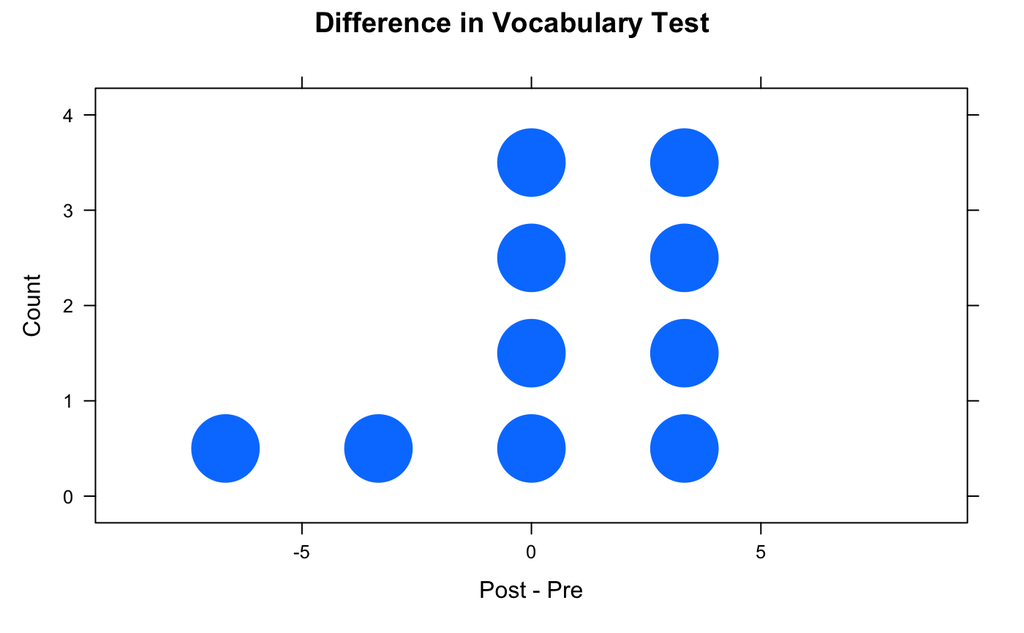

```r
dotPlot(~ post - pre, # subtract pre scores from post scores
        data = vocab_spread, # using our initial data set that had the scores in two separate columns
        main = "Difference in Vocabulary Test", # main title (above plot)
        xlab = "Post - Pre") # label for x-axis
```

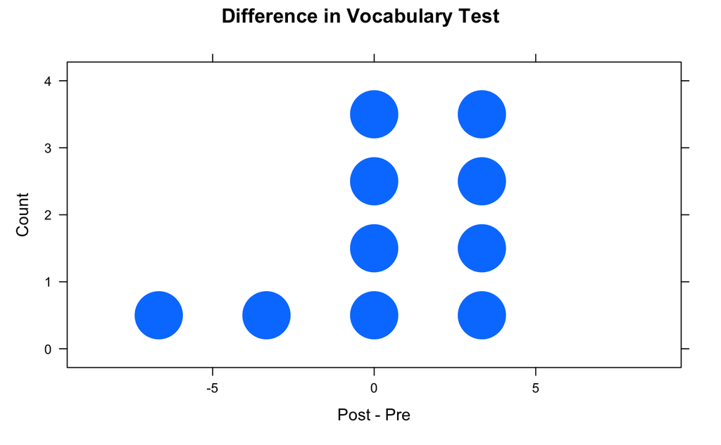

```r
dotPlot(~diff, data = vocab_diff, main = "Difference in Vocabulary Test", xlab = "Post - Pre")
```

## Conducting a two-sample *t*-test

Suppose you have obtained a random sample of male students and a random sample of female students and you would like to compare these two groups on scores on a particular test. In this case, we have two independent samples—there is no reason for us to believe each male in one sample would be paired or matched with one particular female in the other sample. A two-sample *t*-test is therefore in order.

Before we do a *t*-test, it is a good idea to graph the data, separately by group. To see how to do this, refer to the section: “Comparing 2 groups on a quantitative variable” in the “Basic R Analysis Guide”.

Just like you saw above in the paired *t*-test, the `t_test` function expects only one column for the quantitative variable. Again, here you structure your data by putting all of the scores for both groups in one column, and then you have a second column that identifies the gender for that particular score. This is particularly important for two-sample *t*-tests because you may not always have the same number of observations in each group!

Note that below, we are using `"M"` and `"F"` to stand for males and females, respectively. You could also use numerical codes if you wanted (i.e., you could type in a 1 to stand for Males and a 2 for Females).

| scores | gender |
| --- | --- |
| 85 | M |
| 89 | M |
| 88 | M |
| 75 | M |
| 69 | M |
| 98 | M |
| 100 | M |
| 49 | M |
| 58 | M |
| 96 | M |

[output cut: 14 more lines]

If your data is entered as shown above, the appropriate syntax for conducting the two-sample *t*-test is just the same as the paired case, with our response variable, `scores`, appearing on the left side of the formula and our explanatory variable, `gender`, appearing on the right. The only difference is we type `paired = FALSE`, since we only have one observation per student.

```r
t_test(scores ~ gender, data = test2, paired = FALSE, mu = 0, conf.level = 0.95)
```

```
    Welch Two Sample t-test

data:  scores by gender
t = 0.42814, df = 20.059, p-value = 0.6731
alternative hypothesis: true difference in means between group F and group M is not equal to 0
95 percent confidence interval:
 -9.355355 14.188688
sample estimates:
mean in group F mean in group M
       83.33333        80.91667
```

As in the previous 3 sections, the arguments in the `t_test()` function may be changed to fit our analysis (e.g., confidence level, direction of alternative).

Also, by default the two-sample t-test in R assumes unequal variances. The assumption of equal population variances between the two groups is usually not valid, but it is the default in some other statistical software packages. If you wish to assume equal variances in order to compare your results to other statistical software packages, use the syntax below that modifies the `var.equal=` argument in the `t_test()` function.

```r
t_test(scores ~ gender, data = test2, paired = FALSE, mu = 0, conf.level = 0.95, var.equal = TRUE)
```

```
    Two Sample t-test

data:  scores by gender
t = 0.42814, df = 22, p-value = 0.6727
alternative hypothesis: true difference in means between group F and group M is not equal to 0
95 percent confidence interval:
 -9.289328 14.122661
sample estimates:
mean in group F mean in group M
       83.33333        80.91667
```

## Categorical Variables

### Chi-square test of independence

To determine how two categorical variables relate (like gender and political party affiliation), we can use the chi-square test of independence. Here, we have a sample of males and females, and each male (M) and female (F) is categorized as being either Republican (R) or Democrat (D). Is there a significant relationship between gender and politics? To begin, we will first read in a `.csv` file and we’ll name our object `gp` (for Gender Politics). As you see below, once we read in the file and then type our object name, we can see the data. We have two columns in our data set corresponding to gender and politics.

| gender | politics |
| --- | --- |
| M | R |
| M | D |
| F | D |
| M | R |
| F | R |
| F | D |
| F | D |
| M | R |
| M | R |
| F | R |

[output cut: 5 more lines]

Recall that we can create a contingency table using the `tally()` command (see the section “Describing two categorical variables” in the “Basic R Analysis Guide”).

```r
gp_tally
```

```
      politics
gender D R
     F 4 4
     M 3 4
```

To calculate the chi-square test and associated statistics, we use the function `xchisq.test()`, using the same formula that we would use to create the table. We type in `correct = FALSE` because without this, R automatically conducts a more conservative chi-square analysis by applying something called the Yates’ Continuity Correction. This is beyond the scope of this class, but we will not be using this continuity correction here.

```r
xchisq.test(~ gender + politics, data = gp, correct = FALSE)
```

```
    Pearson's Chi-squared test

data:  x
X-squared = 0.076531, df = 1, p-value = 0.7821

   4        4
 (3.73)   (4.27)
[0.019]  [0.017]
< 0.14>  <-0.13>

   3        4
 (3.27)   (3.73)
[0.022]  [0.019]
<-0.15>  < 0.14>

key:
    observed
    (expected)
    [contribution to X-squared]
    <Pearson residual>
```

The output includes a key which tells us that each cell includes the observed counts (which match the table shown above), the expected cell counts in parentheses below it, the cell’s contribution to the overall chi-squared value, and the Pearson residual value for each cell. In this course, we will not be directly using the latter two values given for each cell.

## Inference for proportions

### Creating a Confidence Interval for a Single Proportion

Suppose you collected data on the proportion of Major League Baseball (MLB) games where the home team won: the home team won 1334 out of 2430 games in 2009.

To create a confidence interval for a proportion, you need to have the *count* of “successes” and not the *proportion* of “successes”. So, if in the above example, you were given the following information:

*54.9% of the 2430 MLB games had the home team winning*

you need to convert the percent or proportion of “successes” into a count. So .549*2430 is approximately 1334. In `prop.test()`, `x` = the number of “successes” and `n` = sample size. Again, we specify `correct = FALSE` to not apply Yates’ Continuity Correction, which again is beyond the scope of this class.

```r
prop.test(x = 1334, n = 2430, correct = FALSE)
```

```
    1-sample proportions test without continuity correction

data:  1334 out of 2430
X-squared = 23.31, df = 1, p-value = 1.379e-06
alternative hypothesis: true p is not equal to 0.5
95 percent confidence interval:
 0.5291250 0.5686628
sample estimates:
        p
0.5489712
```

By default, a 95% confidence level is computed, but you can change the level of confidence by typing in a new value. For example, if you would rather have a 90% confidence level, type `conf.level = .90` rather than `conf.level= .95`.

```r
prop.test(x = 1334, n = 2430, correct = FALSE, conf.level = .90)
```

```
    1-sample proportions test without continuity correction

data:  1334 out of 2430
X-squared = 23.31, df = 1, p-value = 1.379e-06
alternative hypothesis: true p is not equal to 0.5
90 percent confidence interval:
 0.5323223 0.5655111
sample estimates:
        p
0.5489712
```

### Conducting a Test for a Single Proportion

Using the same example as above, suppose we want to test the claim that the proportion of winning for the home team in MLB is 50/50.

$$\begin{eqnarray}
H_0: & p = 0.5 \\
H_a: &p \neq 0.5
\end{eqnarray}$$
This is actually already calculated in the output from the `prop.test()` that is shown above. By default, the population parameter is set to not equal to 0.5 (i.e., *p* ≠ 0.5) for the alternative hypothesis (a two-sided or two-tailed test).

```r
prop.test(x = 1334, n = 2430, correct = FALSE)
```

```
    1-sample proportions test without continuity correction

data:  1334 out of 2430
X-squared = 23.31, df = 1, p-value = 1.379e-06
alternative hypothesis: true p is not equal to 0.5
95 percent confidence interval:
 0.5291250 0.5686628
sample estimates:
        p
0.5489712
```

The above can be modified if we want to test different null and alternative hypotheses, other than the two-sided. Suppose we want to test if *p* is equal to, or less than, 0.3:

$$\begin{eqnarray}
H_0: & p = 0.3 \\
H_a: & p < 0.3
\end{eqnarray}$$
we can specify `p = 0.3` (*p* is the hypothesized null value) and `alternative = "less"`.

```r
prop.test(x = 1334, n = 2430, p = 0.3, correct = FALSE, alternative = "less")
```

```
    1-sample proportions test without continuity correction

data:  1334 out of 2430
X-squared = 717.27, df = 1, p-value = 1
alternative hypothesis: true p is less than 0.3
95 percent confidence interval:
 0.0000000 0.5655111
sample estimates:
        p
0.5489712
```

If we want to test the “greater than” hypothesis for `p = 0.3`,

$$\begin{eqnarray}
H_0: &p = 0.3 \\
H_a: &p > 0.3
\end{eqnarray}$$
we can specify `alternative = "greater"`.

### Conducting a Test (and Computing a Confidence Interval) for a Difference in Proportions

Suppose you have obtained a random sample of flights for two airlines and you would like to compare these two airlines on proportion of late arrivals. A two-sample *z*-test is therefore in order.

$$\begin{eqnarray}
H_0: &p_A - p_B = 0 & \text{OR} & p_A = p_B \\
H_a: &p_A - p_B \neq 0 &\text{OR} & p_A \neq p_B
\end{eqnarray}$$

For Airline A, 151 out of 700 flights were late and for Airline B, 87 out of 500 flights were late.

We can still use `prop.test` here. Now, we simply specify both of the “successes” (i.e. late flights), and both of the sample sizes, making sure that we are consistent in the order that we list these. Below the first success and the first sample size represents airline A, and the second success and the second sample size represents airline B.

```r
prop.test(x = c(151, 87), n = c(700, 500), correct = FALSE, conf.level = 0.95)
```

```
    2-sample test for equality of proportions without continuity correction

data:  c out of c151 out of 70087 out of 500
X-squared = 3.192, df = 1, p-value = 0.074
alternative hypothesis: two.sided
95 percent confidence interval:
 -0.003370682  0.086799254
sample estimates:
   prop 1    prop 2
0.2157143 0.1740000
```

## Regression

### Correlation and Simple Linear Regression

To determine if two quantitative variables are related to one another, we can calculate the correlation between the two variables. We can also create an equation that can be used to predict one of these quantitative variables from another. Here, we will focus on whether high school GPA (`GPA`) can predict students’ scores on the SAT (`SAT`).

```r
gpa.sat <- read_csv("GPA-SAT.csv")
```

It is important to get into the habit of creating a scatterplot before computing the correlation coefficient and obtaining the regression equation to make sure the relationship between the variables in question is linear.

We can create this using `xyplot()`. Since `SAT` is our response variable, and `GPA` or explanatory variable, we put `SAT` on the left-hand side so that it shows up on the *y*-axis of the plot.

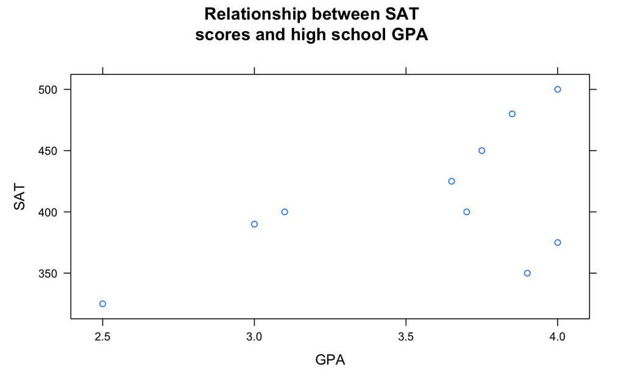

To obtain the correlation between GPA and SAT score, use the `cor()` function as shown below:

```r
cor(SAT ~ GPA, data = gpa.sat)
```

```
[1] 0.5472308
```

The arguments for the `cor()` function are the two variables you are interested in correlating as shown in the formula. The number above, `0.5472308`, is the value of *r*, the Pearson Product-Moment Correlation Coefficient.

The `lm()` function will be used to get the regression equation that can be used to predict SAT score from GPA. Just like on the plot above, we put the response variable, `SAT`, on the left side of the `~` in the equation, and we put our explanatory variable, `GPA`, on the right side.

Fitting a regression returns a lot of results, not all of which R prints. So, we first assign the output of `lm()` to a new object, `sat_model`, and then we use the `summary()` command to see basic details about the model:

```r
sat_model <- lm(SAT ~ GPA, data = gpa.sat)

summary(sat_model)
```

```
Call:
lm(formula = SAT ~ GPA, data = gpa.sat)

Residuals:
   Min     1Q Median     3Q    Max
-80.74 -21.17  11.17  25.46  63.27

Coefficients:
            Estimate Std. Error t value Pr(>|t|)
(Intercept)   197.36     115.76   1.705    0.127
GPA            59.84      32.36   1.849    0.102

Residual standard error: 49.05 on 8 degrees of freedom
Multiple R-squared:  0.2995,    Adjusted R-squared:  0.2119
F-statistic:  3.42 on 1 and 8 DF,  p-value: 0.1016
```

To obtain the regression equation information, you need to use the `summary()` function on the `lm()` object name, so for the example above, the syntax is `summary(sat_model)`. The predicted equation from the output above is:
$$\text{Predicted SAT} = 197.36 + 59.84\cdot\text{GPA}$$
You can find the regression coefficients under the `Coefficients` section of the output and then under the column labeled `Estimate`. The estimated intercept value is the first row and the estimated slope value is in the second row.

You can also add the regression line to the scatterplot by adding the argument `type = c("p", "r")` (to plot both the **p**oints and the **r**egression line) to `xyplot()`:

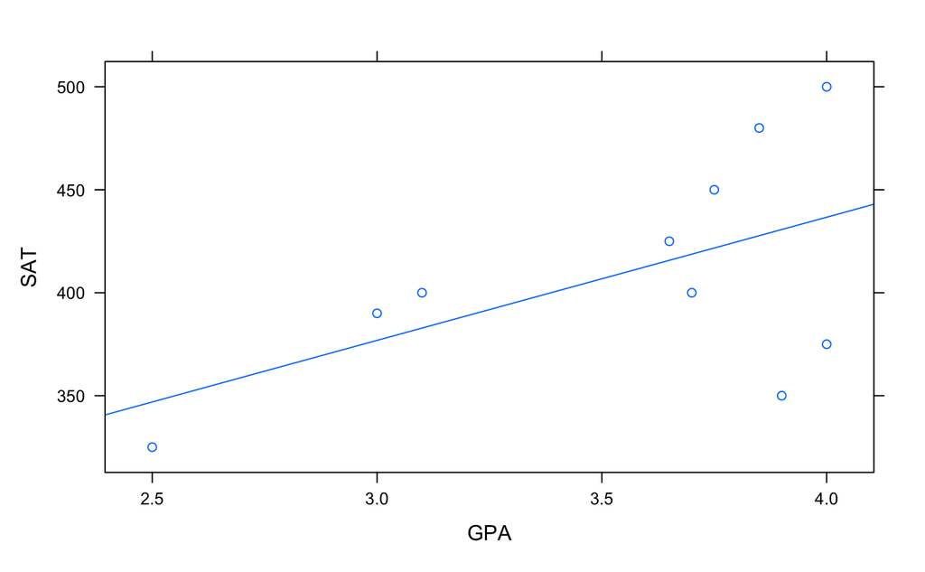

### Creating Residual Plots

When you create a regression model, R will save the residuals and fitted values for you. The `fortify()` function (which the `mosaic` package loads for you) creates a data frame for you that makes these values easy to plot.

```r
gpa.sat_fortified <- fortify(sat_model)

gpa.sat_fortified
```

|  | SAT | GPA | .hat | .sigma | .cooksd | .fitted | .resid | .stdresid |
| --- | --- | --- | --- | --- | --- | --- | --- | --- |
| 1 | 480 | 3.85 | 0.1404941 | 47.91286 | 0.107901132 | 427.7522 | 52.247796 | 1.1490090 |
| 2 | 425 | 3.65 | 0.1047992 | 52.30495 | 0.002308738 | 415.7835 | 9.216454 | 0.1986020 |
| 3 | 400 | 3.70 | 0.1104582 | 51.89170 | 0.010227926 | 418.7757 | -18.775710 | -0.4058757 |
| 4 | 500 | 4.00 | 0.1901186 | 45.20197 | 0.241171057 | 436.7287 | 63.271303 | 1.4334283 |
| 5 | 390 | 3.00 | 0.2292959 | 52.12948 | 0.013799407 | 376.8854 | 13.114594 | 0.3045726 |
| 6 | 350 | 3.90 | 0.1548591 | 40.58723 | 0.293787065 | 430.7444 | -80.744368 | -1.7907196 |
| 7 | 375 | 4.00 | 0.1901186 | 45.57665 | 0.229554525 | 436.7287 | -61.728697 | -1.3984802 |
| 8 | 325 | 2.50 | 0.5753618 | 50.86326 | 0.319923587 | 346.9638 | -21.963761 | -0.6871904 |
| 9 | 400 | 3.10 | 0.1862009 | 51.94084 | 0.017147677 | 382.8697 | 17.130264 | 0.3871554 |
| 10 | 450 | 3.75 | 0.1182936 | 51.18810 | 0.025207529 | 421.7679 | 28.232125 | 0.6130014 |

The columns `.fitted` are the fitted values and `.resid` are the residuals.

We can plot these values just like any other value in R. To make a histogram of the residuals, simply type the following command, just like you learned in the “Basic R Analysis Guide”.

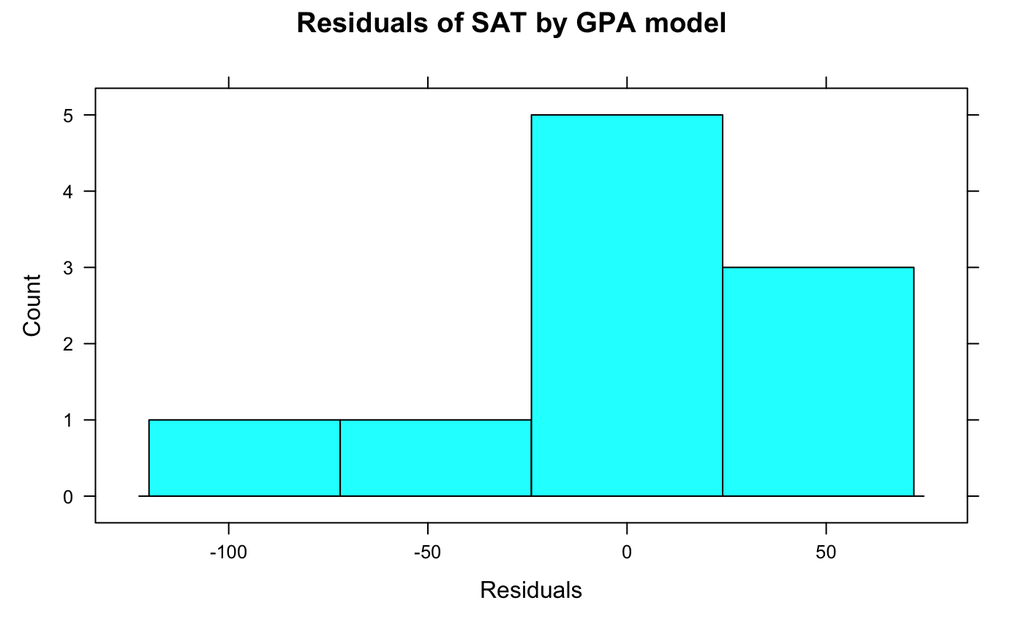

```r
histogram(~ .resid, data = gpa.sat_fortified, type = "count", main = "Residuals of SAT by GPA model", xlab = "Residuals")
```

To make a scatterplot of the residuals vs. the fitted values, type the following command:

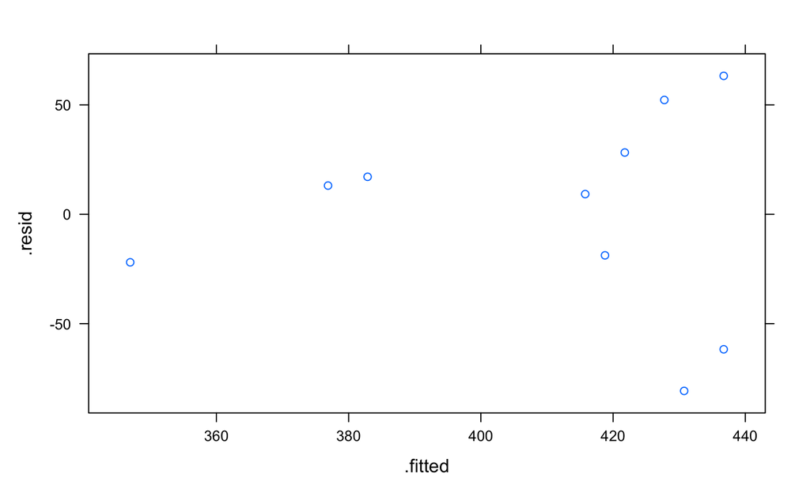

```r
xyplot(.resid ~ .fitted, data = gpa.sat_fortified)
```

Alternatively, R outputs this same residual plot as the first of the 4 plots produced by the `plot()` for the model object, here `sat_model`, along with some extra annotations and information:

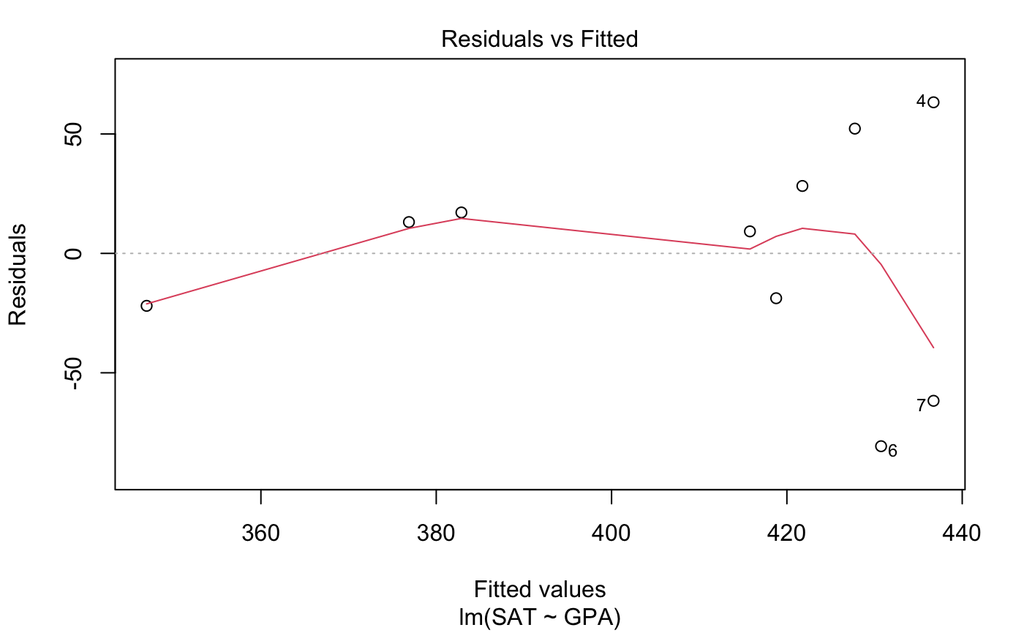

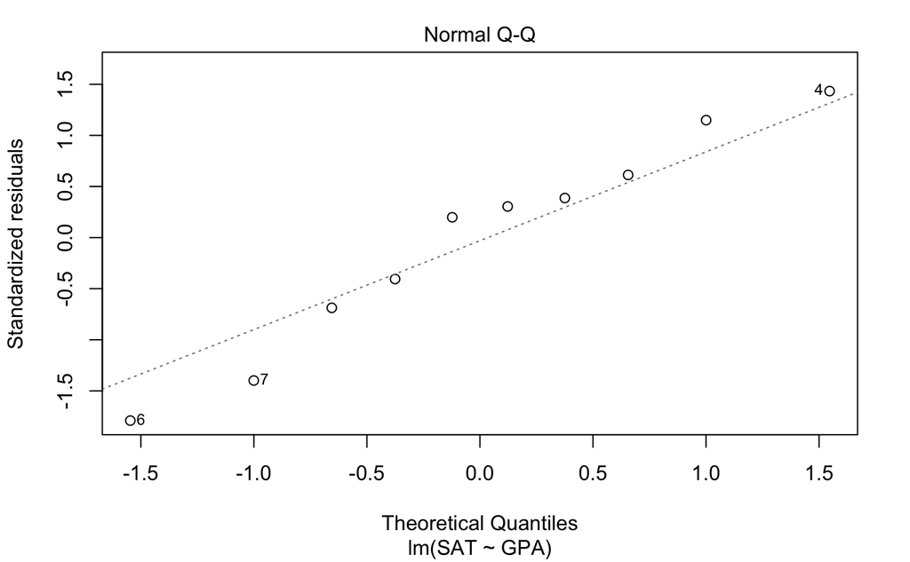

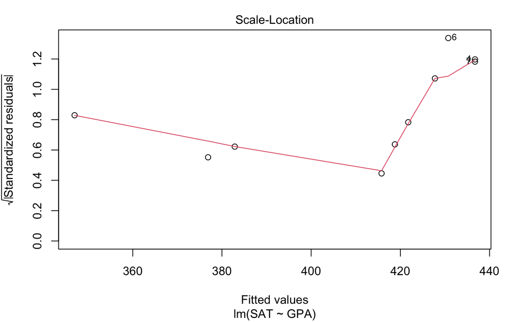

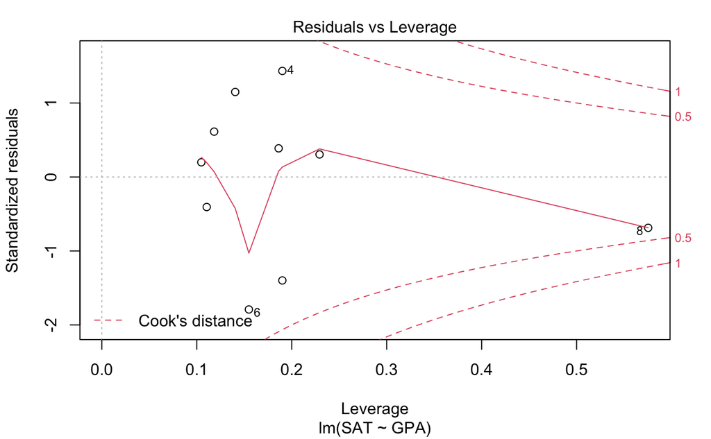

```r
plot(sat_model)
```

R identifies the numbers of the most extreme observations in the first of these four plots so that you can go back and examine your dataset. The other 3 plots shown are also useful, but beyond the scope of this course. You can learn more about regression analysis in EPSY 5262!